# Kaggle Costumer Cluster

Romario

2023-03-21

# Introdução

O conjunto de dados foi retirado do [Kaggle](https://www.kaggle.com/datasets/whenamancodes/customer-personality-analysis) e pretende agrupar os clientes de forma que ajudem o grupo de marketing em suas campanhas

## Bibliotecas

```r
library(tidyverse)
library(here)
library(DT)
library(cluster)
library(factoextra)
library("ggsci")
library(cluster)
library('RVAideMemoire')
library(flextable)
library(rstatix)
```

## Dataset Informations

```r
data=read_tsv(here('data/marketing_campaign.csv'))
DT::datatable(data, options = list(searching = FALSE,pageLength = 5,lengthMenu = c(5, 10, 15, 20), scrollX = T))
```

|  | ID | Year_Birth | Education | Marital_Status | Income | Kidhome | Teenhome | Dt_Customer | Recency | MntWines | MntFruits | MntMeatProducts | MntFishProducts | MntSweetProducts | MntGoldProds | NumDealsPurchases | NumWebPurchases | NumCatalogPurchases | NumStorePurchases | NumWebVisitsMonth | AcceptedCmp3 | AcceptedCmp4 | AcceptedCmp5 | AcceptedCmp1 | AcceptedCmp2 | Complain | Z_CostContact | Z_Revenue | Response |
| --- | --- | --- | --- | --- | --- | --- | --- | --- | --- | --- | --- | --- | --- | --- | --- | --- | --- | --- | --- | --- | --- | --- | --- | --- | --- | --- | --- | --- | --- |
| 1 | 5524 | 1957 | Graduation | Single | 58138 | 0 | 0 | 04-09-2012 | 58 | 635 | 88 | 546 | 172 | 88 | 88 | 3 | 8 | 10 | 4 | 7 | 0 | 0 | 0 | 0 | 0 | 0 | 3 | 11 | 1 |
| 2 | 2174 | 1954 | Graduation | Single | 46344 | 1 | 1 | 08-03-2014 | 38 | 11 | 1 | 6 | 2 | 1 | 6 | 2 | 1 | 1 | 2 | 5 | 0 | 0 | 0 | 0 | 0 | 0 | 3 | 11 | 0 |
| 3 | 4141 | 1965 | Graduation | Together | 71613 | 0 | 0 | 21-08-2013 | 26 | 426 | 49 | 127 | 111 | 21 | 42 | 1 | 8 | 2 | 10 | 4 | 0 | 0 | 0 | 0 | 0 | 0 | 3 | 11 | 0 |
| 4 | 6182 | 1984 | Graduation | Together | 26646 | 1 | 0 | 10-02-2014 | 26 | 11 | 4 | 20 | 10 | 3 | 5 | 2 | 2 | 0 | 4 | 6 | 0 | 0 | 0 | 0 | 0 | 0 | 3 | 11 | 0 |
| 5 | 5324 | 1981 | PhD | Married | 58293 | 1 | 0 | 19-01-2014 | 94 | 173 | 43 | 118 | 46 | 27 | 15 | 5 | 5 | 3 | 6 | 5 | 0 | 0 | 0 | 0 | 0 | 0 | 3 | 11 | 0 |
| 6 | 7446 | 1967 | Master | Together | 62513 | 0 | 1 | 09-09-2013 | 16 | 520 | 42 | 98 | 0 | 42 | 14 | 2 | 6 | 4 | 10 | 6 | 0 | 0 | 0 | 0 | 0 | 0 | 3 | 11 | 0 |
| 7 | 965 | 1971 | Graduation | Divorced | 55635 | 0 | 1 | 13-11-2012 | 34 | 235 | 65 | 164 | 50 | 49 | 27 | 4 | 7 | 3 | 7 | 6 | 0 | 0 | 0 | 0 | 0 | 0 | 3 | 11 | 0 |
| 8 | 6177 | 1985 | PhD | Married | 33454 | 1 | 0 | 08-05-2013 | 32 | 76 | 10 | 56 | 3 | 1 | 23 | 2 | 4 | 0 | 4 | 8 | 0 | 0 | 0 | 0 | 0 | 0 | 3 | 11 | 0 |
| 9 | 4855 | 1974 | PhD | Together | 30351 | 1 | 0 | 06-06-2013 | 19 | 14 | 0 | 24 | 3 | 3 | 2 | 1 | 3 | 0 | 2 | 9 | 0 | 0 | 0 | 0 | 0 | 0 | 3 | 11 | 1 |
| 10 | 5899 | 1950 | PhD | Together | 5648 | 1 | 1 | 13-03-2014 | 68 | 28 | 0 | 6 | 1 | 1 | 13 | 1 | 1 | 0 | 0 | 20 | 1 | 0 | 0 | 0 | 0 | 0 | 3 | 11 | 0 |

[output cut: 2230 more lines]

## Tratando os dados

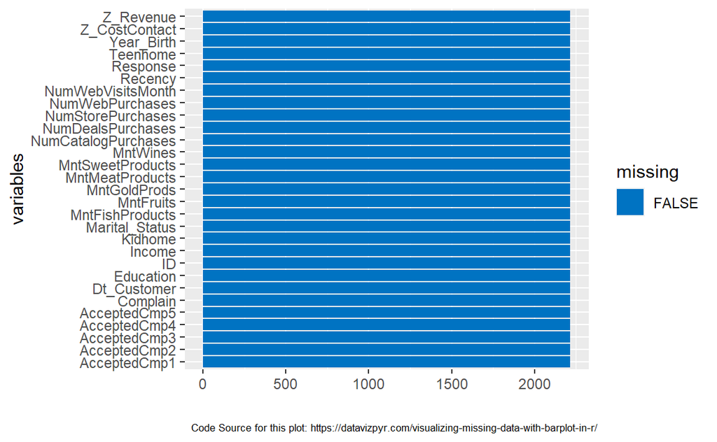

```r
data=na.omit(data)


change_to_factors=c("Complain","AcceptedCmp1", "AcceptedCmp2", 'AcceptedCmp3', 'AcceptedCmp4',
                    'AcceptedCmp5','Education','Marital_Status',"Year_Birth","Response")

data_to_change = data

data_to_change[change_to_factors] =lapply(data_to_change[change_to_factors],as.factor)
data_to_change[change_to_factors] = lapply(data_to_change[change_to_factors],unclass) #transforma os fatores em numeros

rm(change_to_factors)

#Assume que esses dados não são relevantes
data_selected_columns= data_to_change |> dplyr::select(!c('ID','Dt_Customer','Z_CostContact',"Z_Revenue"))
rm(data_to_change)

data |>
  summarise_all(list(~is.na(.))) |>
  pivot_longer(everything(),
               names_to = "variables", values_to="missing") |>
  count(variables, missing) |>
  ggplot(aes(y=variables,x=n,fill=missing))+
  geom_col() +
  xlab("") +
  scale_fill_jco() +
  labs(caption="Code Source for this plot: https://datavizpyr.com/visualizing-missing-data-with-barplot-in-r/ ") +
  theme(
    plot.caption=element_text(hjust=-1.2,size=6.5)
  )
```

## Construindo o modelo de clusterização

Escolhi o algoritmo [`Clara`](http://wiki.icmc.usp.br/images/a/a8/CLARANS_DiegoAmancio.pdf), pois ele trabalha bem com grandes bancos de dados.

```r
# O banco de dados deve ser normalizado
data_selected_columns_scaled = apply(as.matrix(data_selected_columns),2,as.numeric) |> scale()

rm(data_selected_columns)
```

O gráfico auxilia na escolha do número de clusters ou grupos.

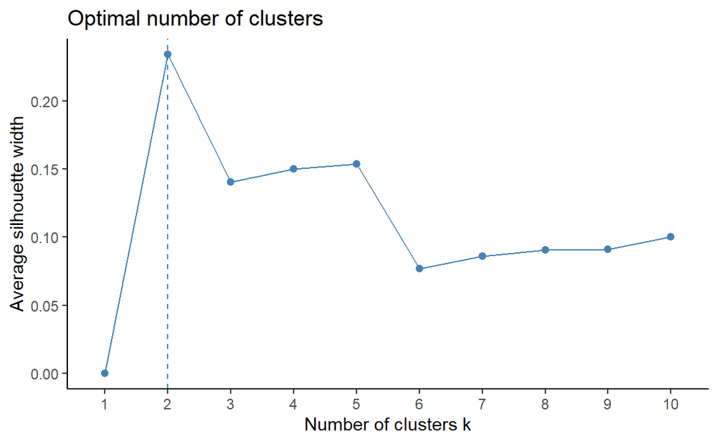

```r
fviz_nbclust(data_selected_columns_scaled, clara, method = "silhouette")+
  theme_classic()
```

Agrupando os clientes

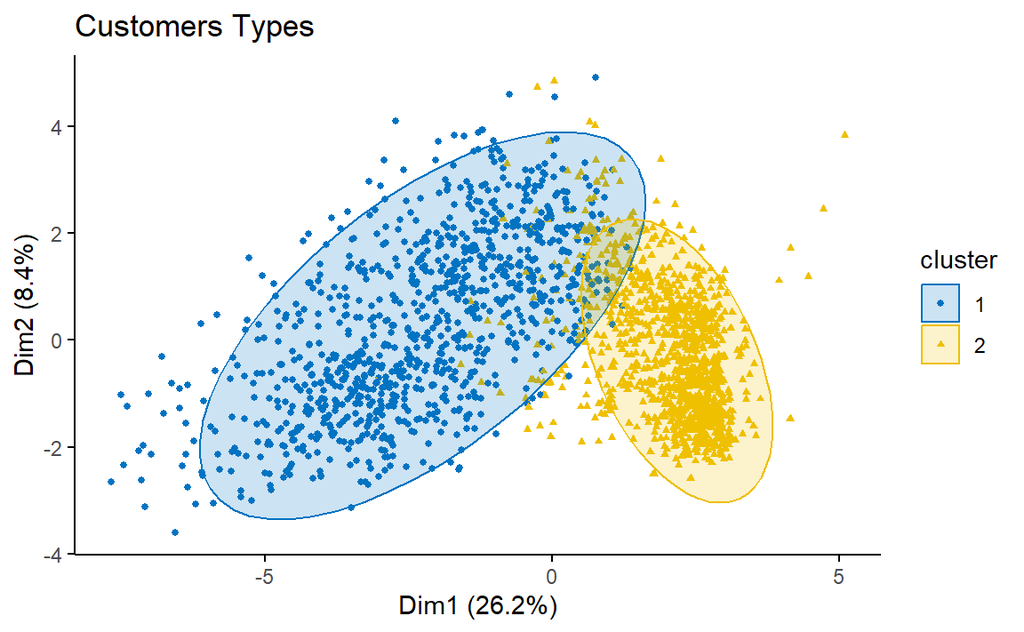

```r
clara_cluster_for_data<- clara(data_selected_columns_scaled, 2, samples = 50, pamLike = TRUE)

customers_types= fviz_cluster(clara_cluster_for_data,
             palette = 'jco',
             ellipse.type = "t",
             geom = "point", pointsize = 1,
             ggtheme = theme_classic(),
             main="Customers Types"
)

customers_types
```

```r
#Unindo a segmentação com o banco de dados originais
dataset=(cbind(data, cluster = clara_cluster_for_data$cluster))
```

## Analisando os clientes

### Renda

A equipe de marketing precisa bater suas metas. Perceberam que dividi os grupos entre 1 e 2. Então me pediram para analisar quais dos dois grupos possuem os clientes com maior renda.

Aparentemente eles querem focar nos ricaços.

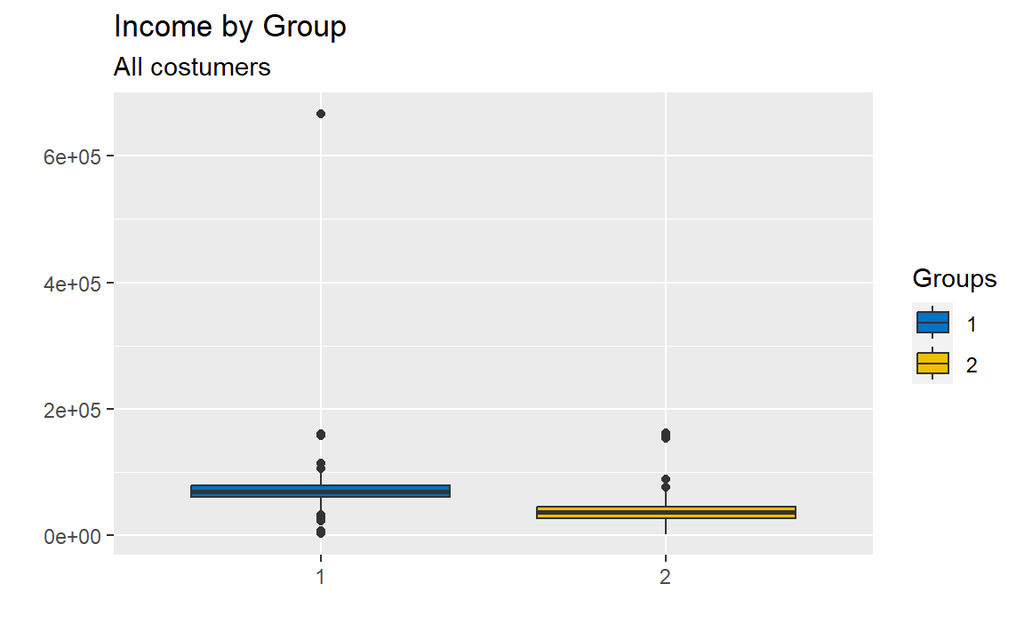

```r
dataset |>
  ggplot() +
  geom_boxplot(aes(x = as.factor(cluster), y = Income, fill = as.factor(cluster))) +
  labs(x = "",
       y = "",
       title = "Income by Group",
       subtitle = "All costumers",
       fill="Groups"
       ) +
  scale_fill_jco()
```

O gráfico de caixa mostra como se espalha a renda anual entre os clientes. Parece haver diferença entre a mediana dos dois grupos. Entretanto, o grupo de marketing não está convencido. Devo utilizar outra visualização?

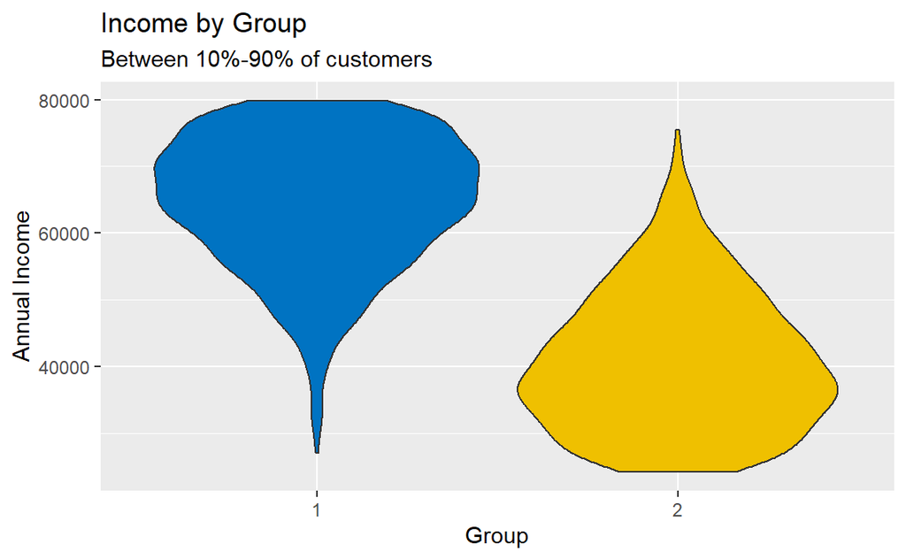

```r
dataset |>
  ggplot(aes(x = as.factor(cluster), y = Income, fill = as.factor(cluster))) +
  geom_violin() +
  labs(x = "Group",
       y = "Annual Income",
       title = "Income by Group",
       subtitle= "Between 10%-90% of customers"
       ) +
  scale_fill_jco()+
  theme(legend.position = "none") +
  scale_y_continuous(limits = quantile(dataset$Income,c(0.1, 0.9)))
```

Opa! Agora sim! Escolhendo os valores entre 10 e 90 quartis, eu pude provar para o grupo de marketing uma não apenas uma diferença na mediana de renda, como a maioria dos clientes do grupo 1 tem altos salários e do grupo dois são pessoas comuns.

O marketing sai feliz da sala e me dá tapas nas costas. Mas me bateu uma culpa. Será que *REALMENTE* tem diferenças entre os grupos? Para isso é necessário realizar teste de hipóteses e avaliar suas premissas.

### A Renda é realmente diferente?

A solução é a realização de um teste t ou wilcox. Para saber qual utilizar e é necessário avaliar se estados estão em uma distribuição normal.

Isto pode ser verificado utilizando o teste de Shapiro-Wilk. Se indicar normalidade, hipótese nula, usaremos o teste t que irá comparar a média da Renda. Em casos não haja normalidade, usaremos a wilcox que compara as medianas.

```r
byf.shapiro(Income ~cluster, data=dataset)
```

```
##
##  Shapiro-Wilk normality tests
##
## data:  Income by cluster
##
##        W   p-value
## 1 0.4459 < 2.2e-16 ***
## 2 0.9213 < 2.2e-16 ***
## ---
## Signif. codes:  0 '***' 0.001 '**' 0.01 '*' 0.05 '.' 0.1 ' ' 1
```

O p < 0,05, nos faz descartar a hipótese nula, ou seja, iremos comparar a mediana.

```r
wilcox.test(Income ~ cluster, data = dataset)
```

```
##
##  Wilcoxon rank sum test with continuity correction
##
## data:  Income by cluster
## W = 1168394, p-value < 2.2e-16
## alternative hypothesis: true location shift is not equal to 0
```

Sim! As duas medianas são diferentes! Ufa, não fiz o marketing perder tempo.

```r
dataset |>
  group_by(cluster) |>
  get_summary_stats(Income, type = "median_iqr") |>
  flextable() |>
  set_header_labels(cluster = "Grupo", variable = "Variavél", n = "Quantidade",
                    median = "Mediana", iqr = "IIQ")
```

| Grupo | Variavél | Quantidade | Mediana | IIQ |
| --- | --- | --- | --- | --- |
| 1 | Income | 1,038 | 69,275.0 | 17,602.25 |
| 2 | Income | 1,178 | 36,630.5 | 18,527.50 |

## O que vender

A equipe marketing voltou… Ok, eles sabem haver uma diferença de ganhos entre os grupos, mas mesmo assim, tem diferença entre no que eles gastam?

Então eles me informaram que estão com campanhas no setor de: vinho, frutas e ouro.

Para analisar iremos refazer os de normalidade de comparar as medianas

### Vinho

```r
byf.shapiro(MntWines ~cluster, data=dataset) #Os dados não são normais
```

```
##
##  Shapiro-Wilk normality tests
##
## data:  MntWines by cluster
##
##        W   p-value
## 1 0.9649 3.959e-15 ***
## 2 0.5975 < 2.2e-16 ***
## ---
## Signif. codes:  0 '***' 0.001 '**' 0.01 '*' 0.05 '.' 0.1 ' ' 1
```

```r
wilcox.test(MntWines ~ cluster, data = dataset) #A renda entre os dois gupos não é normal
```

```
##
##  Wilcoxon rank sum test with continuity correction
##
## data:  MntWines by cluster
## W = 1164575, p-value < 2.2e-16
## alternative hypothesis: true location shift is not equal to 0
```

```r
dunn_test(MntWines ~ cluster, data = dataset, p.adjust.method = "bonferroni")
```

```
## # A tibble: 1 × 9
##   .y.      group1 group2    n1    n2 statistic         p     p.adj p.adj.signif
## * <chr>    <chr>  <chr>  <int> <int>     <dbl>     <dbl>     <dbl> <chr>
## 1 MntWines 1      2       1038  1178     -36.8 1.46e-296 1.46e-296 ****
```

```r
dataset |>
  group_by(cluster) |>
  get_summary_stats(MntWines, type = "median_iqr") |>
  flextable() |>
  set_header_labels(cluster = "Grupo", variable = "Variavél", n = "Quantidade",
                    median = "Mediana", iqr = "IIQ")
```

| Grupo | Variavél | Quantidade | Mediana | IIQ |
| --- | --- | --- | --- | --- |
| 1 | MntWines | 1,038 | 515.5 | 440 |
| 2 | MntWines | 1,178 | 27.0 | 82 |

O grupo 1 gastou mais com vinhos.

### Frutas

```r
byf.shapiro(MntFruits ~cluster, data=dataset) #Os dados não são normais
```

```
##
##  Shapiro-Wilk normality tests
##
## data:  MntFruits by cluster
##
##        W   p-value
## 1 0.8640 < 2.2e-16 ***
## 2 0.5703 < 2.2e-16 ***
## ---
## Signif. codes:  0 '***' 0.001 '**' 0.01 '*' 0.05 '.' 0.1 ' ' 1
```

```r
wilcox.test(MntFruits~ cluster, data = dataset) #A renda entre os dois gupos não é normal
```

```
##
##  Wilcoxon rank sum test with continuity correction
##
## data:  MntFruits by cluster
## W = 1047484, p-value < 2.2e-16
## alternative hypothesis: true location shift is not equal to 0
```

```r
dataset |>
  group_by(cluster) |>
  get_summary_stats(MntFruits, type = "median_iqr") |>
  flextable() |>
  set_header_labels(cluster = "Grupo", variable = "Variavél", n = "Quantidade",
                    median = "Mediana", iqr = "IIQ")
```

| Grupo | Variavél | Quantidade | Mediana | IIQ |
| --- | --- | --- | --- | --- |
| 1 | MntFruits | 1,038 | 32 | 59.75 |
| 2 | MntFruits | 1,178 | 3 | 7.00 |

O grupo 1 gastou mais com frutas

### Ouro

```r
byf.shapiro(MntGoldProds ~cluster, data=dataset) #Os dados não são normais
```

```
##
##  Shapiro-Wilk normality tests
##
## data:  MntGoldProds by cluster
##
##        W   p-value
## 1 0.8804 < 2.2e-16 ***
## 2 0.6548 < 2.2e-16 ***
## ---
## Signif. codes:  0 '***' 0.001 '**' 0.01 '*' 0.05 '.' 0.1 ' ' 1
```

```r
wilcox.test(MntGoldProds~ cluster, data = dataset) #A renda entre os dois gupos não é normal
```

```
##
##  Wilcoxon rank sum test with continuity correction
##
## data:  MntGoldProds by cluster
## W = 1002408, p-value < 2.2e-16
## alternative hypothesis: true location shift is not equal to 0
```

```r
dataset |>
  group_by(cluster) |>
  get_summary_stats(MntGoldProds, type = "median_iqr") |>
  flextable() |>
  set_header_labels(cluster = "Grupo", variable = "Variavél", n = "Quantidade",
                    median = "Mediana", iqr = "IIQ")
```

| Grupo | Variavél | Quantidade | Mediana | IIQ |
| --- | --- | --- | --- | --- |
| 1 | MntGoldProds | 1,038 | 49 | 73 |
| 2 | MntGoldProds | 1,178 | 12 | 20 |

O grupo 1 gastou mais com ouro

Tá, ok. Mas eles vão responder à mensagem? Vão atender ao telefone. Vão fechar a porta na nossa cara? Mesmo com o costume de receber não, o marketing quer evitar a decepção. Então olharam para mim, no fundo dos olhos e perguntaram: “Tem diferença entre os grupos em relação nossas promoções?”

Vamos. Nesse tipo de situação devemos utilizar o teste de chi-quadrado. Ele analise se as chances de algo acontecer é ao caso, ou está ligada a alguma categoria. No nosso caso, é a resposta a campanha.

```r
tbl <- xtabs(~ Response + cluster, data = dataset)
summary(tbl)
```

```
## Call: xtabs(formula = ~Response + cluster, data = dataset)
## Number of cases in table: 2216
## Number of factors: 2
## Test for independence of all factors:
##  Chisq = 42.96, df = 1, p-value = 5.578e-11
```

```r
proportions(tbl, "cluster")
```

```
##         cluster
## Response         1         2
##        0 0.7967245 0.8964346
##        1 0.2032755 0.1035654
```

Apesar o teste indicar que há uma dependência entre o grupo e a probabilidade de atender. Sendo bem sincero com o marketing… A propaganda deles deve ser bem chata. Pois ambos o público tem uma baixa taxa de resposta.

A Partir do R não só penas treinamos um modelo estatístico, como também ajudar nossos colegas de trabalha a vender de forma diferenciada para cada público, e deve melhor suas técnicas de persuasão.

Até a próxima!